# HW3-SyntheticControl

Hakan Ekiz - IE48B - Fall2021

13 Aralık 2021

## Homework Information

### Distance Measurements

1- Euclidian 2- DTW (Windows size=10) 3- DTW (Window size=20) 4- ERP

### K nn classifiers

1- k=1 2- k=3 3- k=5

### Datasets

1- ECG200 2- Plane 3- SyntheticControl 4- Trace 5- SmmothSubspace

Note: Since it takes time to run 5 different datasets in the same file and convert them to reports, 5 different files will be loaded for 5 different datasets.

## Libraries and Functions

```r
require(data.table)
require(ggplot2)
require(repr)
require(rpart)
require(rattle)
require(TSrepr)
require(TSdist)
require(dtw)
require(zoo)
require(genlasso)
require(e1071)
```

```r
options(repr.plot.width=15, repr.plot.height=8)
```

```r
nn_classify_cv=function(dist_matrix,train_class,test_indices,k=1){

    test_distances_to_train=dist_matrix[test_indices,]
    test_distances_to_train=test_distances_to_train[,-test_indices]
    train_class=train_class[-test_indices]
    #print(str(test_distances_to_train))
    ordered_indices=apply(test_distances_to_train,1,order)
    if(k==1){
        nearest_class=as.numeric(trainclass[as.numeric(ordered_indices[1,])])
        nearest_class=data.table(id=test_indices,nearest_class)
    } else {
        nearest_class=apply(ordered_indices[1:k,],2,function(x) {trainclass[x]})
        nearest_class=data.table(id=test_indices,t(nearest_class))
    }

    long_nn_class=melt(nearest_class,'id')

    class_counts=long_nn_class[,.N,list(id,value)]
    class_counts[,predicted_prob:=N/k]
    wide_class_prob_predictions=dcast(class_counts,id~value,value.var='predicted_prob')
    wide_class_prob_predictions[is.na(wide_class_prob_predictions)]=0
    class_predictions=class_counts[,list(predicted=value[which.max(N)]),by=list(id)]


    return(list(prediction=class_predictions,prob_estimates=wide_class_prob_predictions))

}
```

# SyntheticControl

Train Size=300 TestSize=300 Length=60 Number of Class=6

## Data

```r
current_folder=getwd()
dataset='SyntheticControl'
main_path=sprintf('%s/ClassificationData/%s/%s',current_folder,dataset,dataset)

dist_path=sprintf('%s/ClassificationData/%s/distances/%s',current_folder,dataset,dataset)

train_data_path=sprintf('%s_TRAIN.txt',main_path)
traindata=as.matrix(fread(train_data_path))

test_data_path=sprintf('%s_TEST.txt',main_path)
testdata=as.matrix(fread(test_data_path))

#first column is the class variable
trainclass=traindata[,1] # takes -1 and 1
testclass=testdata[,1] # takes -1 and 1

#drop first column
traindata=traindata[,2:ncol(traindata)]
testdata=testdata[,2:ncol(testdata)]

# instance characteristics
tlength=ncol(traindata)
n_series_train=nrow(traindata)
n_series_test=nrow(testdata)
```

```r
head(data.table(traindata))
```

```
##            V2          V3         V4         V5         V6          V7
## 1: -0.3769356  1.22486430  0.3438744  0.3284540 -0.3376094  1.02651400
## 2:  0.6444062  0.41326914 -0.8622785 -1.4973857 -0.4214578 -0.21421485
## 3: -0.9786674 -0.40623244  0.8224286 -1.4082424 -1.6767337 -0.49063202
## 4: -0.2365366 -0.09817465  0.3670918  1.3668598  0.4982812 -0.30022317
## 5:  1.4907351  1.32524300  1.6268292 -0.3170562 -1.0989904 -0.02221261
## 6:  1.6433162  1.76401080  0.4377555  0.1993101 -1.5676161 -0.71911748
##            V8         V9        V10        V11          V12         V13
## 1: -1.3309960 -0.6578003  1.4460774 -0.8463966  0.776208130 -0.25405199
## 2: -1.2921314  0.9568977 -1.2161403 -0.5885358  0.776983860 -0.60302893
## 3:  1.4045976  1.1685996 -1.7032538  0.9728103 -0.761971700 -1.49253140
## 4:  1.7156337  0.9021076 -0.2181317 -1.4307205  1.441399900  1.12494290
## 5:  0.5969804  1.6673392 -0.2061527 -1.3766266  0.009963422 -0.05846121
## 6: -1.0941885  1.0331764 -1.3771657 -0.9489048  1.100883200 -0.29434869
##           V14        V15        V16        V17        V18        V19        V20
```

[output cut: 55 more lines]

```r
dt_ts_train=data.table(traindata)
dt_ts_train[,id:=1:.N]
long_train=melt(dt_ts_train,id.vars=c('id'))
long_train[,time:=as.numeric(gsub("\\D", "", variable))-1]
long_train=long_train[order(id,time)]
long_train[,diff_series:=value-shift(value,1),by=list(id)]
head(long_train)
```

```
##    id variable      value time diff_series
## 1:  1       V2 -0.3769356    1          NA
## 2:  1       V3  1.2248643    2  1.60179988
## 3:  1       V4  0.3438744    3 -0.88098992
## 4:  1       V5  0.3284540    4 -0.01542035
## 5:  1       V6 -0.3376094    5 -0.66606348
## 6:  1       V7  1.0265140    6  1.36412345
```

```r
#head(dt_ts_train)
```

```r
dt_ts_test=data.table(testdata)
dt_ts_test[,id:=1:.N]
long_test=melt(dt_ts_test,id.vars=c('id'))
long_test[,time:=as.numeric(gsub("\\D", "", variable))-1]
long_test=long_test[order(id,time)]
long_test[,diff_series:=value-shift(value,1),by=list(id)]
head(long_test)
```

```
##    id variable      value time diff_series
## 1:  1       V2 -1.4139728    1          NA
## 2:  1       V3 -1.1620647    2   0.2519081
## 3:  1       V4 -0.6241739    3   0.5378908
## 4:  1       V5  0.9396037    4   1.5637776
## 5:  1       V6 -0.5275007    5  -1.4671044
## 6:  1       V7  0.5747866    6   1.1022873
```

```r
#head(dt_ts_test)
```

[figure not shown]

```r
ggplot(long_train, aes(time,value)) + geom_line(aes(color=as.character(id)))
```

## Representations

PAA with segmenth length = 5 PLA with n_important = 10 Tree with maxdepth = 12

```r
#Piecewise Aggregate + Piecewise Linear Approximation + Tree


segmentlength = 5
n_important = 10

long_train=long_train[order(id,time)]

treeres <- vector('list', n_series_train)
paares <- vector('list', n_series_train)

for (i in 1:n_series_train) {

  data_plot=long_train[id==i]

  data_ts=long_train[id==i]$value
  paa_rep=repr_paa(data_ts, segmentlength , meanC)
  dummy_time = c(1:(length(paa_rep)-1))*segmentlength
  dummy_time = c(dummy_time, (nrow(data_plot)))
  dt_paa = data.table(time=dummy_time, paa_rep)

  pla_rep=repr_pla(data_ts, times = n_important, return = "points")
  pla_rep=repr_pla(data_ts, times = n_important, return = "both")
  setnames(pla_rep,c('places','points'),c('time','pla_rep'))
  pla_rep$time=pla_rep$time+1


  tree=rpart(value~time,data_plot,control=rpart.control(cp=0,maxdepth=12,minsplit=20,minbucket=10))
  data_plot[,tree_rep:=predict(tree,data_plot)]


  data_plot=merge(data_plot,dt_paa,by='time',all.x=T)
  data_plot=merge(data_plot,pla_rep,by='time',all.x=T)

  data_plot[,paa_rep:=nafill(paa_rep,'nocb')]
  data_plot[, pla_rep := na.approx(pla_rep)]

  paares[[i]]=data_plot

}
results <- rbindlist(paares)
```

```r
head(results)
```

```
##    time id variable      value diff_series  tree_rep     paa_rep     pla_rep
## 1:    1  1       V2 -0.3769356          NA 0.3987486  0.23652954 -0.37693558
## 2:    2  1       V3  1.2248643  1.60179988 0.3987486  0.23652954 -0.14905896
## 3:    3  1       V4  0.3438744 -0.88098992 0.3987486  0.23652954  0.07881766
## 4:    4  1       V5  0.3284540 -0.01542035 0.3987486  0.23652954  0.30669429
## 5:    5  1       V6 -0.3376094 -0.66606348 0.3987486  0.23652954  0.53457091
## 6:    6  1       V7  1.0265140  1.36412345 0.3987486 -0.07252029  0.76244753
```

Sample representaion for id=10

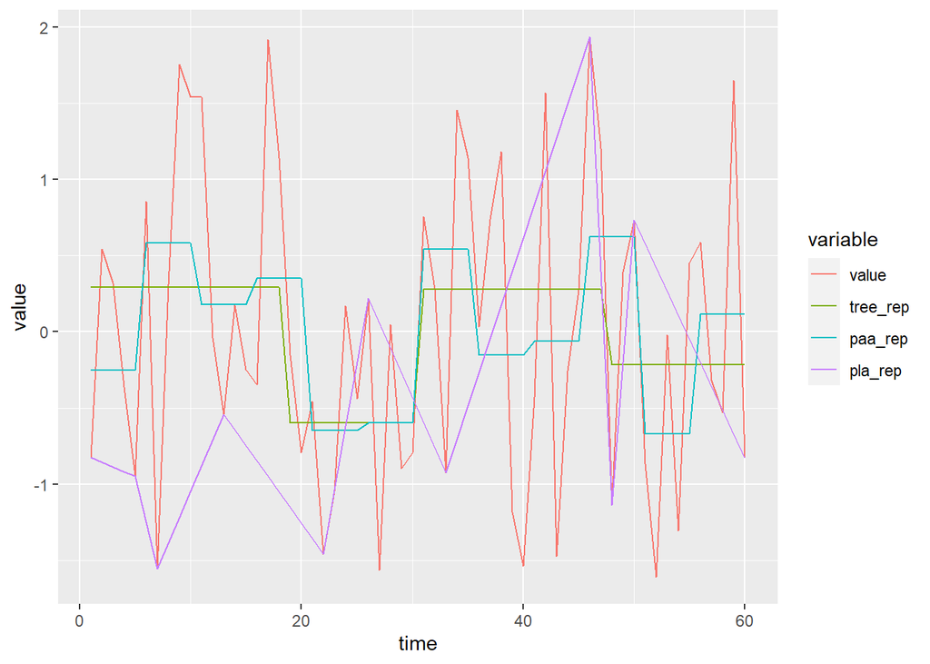

```r
selected=results[id==10]
data_show=melt(selected,id.vars='time',measure.vars=c('value','tree_rep', 'paa_rep', 'pla_rep'))
ggplot(data_show,aes(x=time,y=value,color=variable))+
    geom_line()
```

## Distance Measurement

Preliminary work with results dataset for future distance calculations;

Euc Dtw (window size = 10) Dtw (window size = 20) ERP

```r
value_train=dcast(results[!is.na(value)],id~time,value.var='value')
#head(value_train)
value_train=as.matrix(value_train)
```

```r
diff_train=dcast(results[!is.na(diff_series)],id~time,value.var='diff_series')
#head(diff_train)
diff_train=as.matrix(diff_train)
```

```r
tree_train=dcast(results[!is.na(tree_rep)],id~time,value.var='tree_rep')
#head(tree_train)
tree_train=as.matrix(tree_train)
```

```r
paa_train=dcast(results[!is.na(paa_rep)],id~time,value.var='paa_rep')
#head(paa_train)
paa_train=as.matrix(paa_train)
```

```r
pla_train=dcast(results[!is.na(pla_rep)],id~time,value.var='pla_rep')
#head(pla_train)
pla_train=as.matrix(pla_train)
```

```r
large_number=10000
```

### Euclidian

Raw, difference, tree, paa(piecewise aggregate approximation with segmenth length 5) and pla values are used.

```r
# raw + euc
dist_euc=as.matrix(dist(value_train))
diag(dist_euc)=large_number
fwrite(dist_euc,sprintf('%s_euc_raw_dist.csv',dist_path),col.names=F)
```

```
## x being coerced from class: matrix to data.table
```

```r
# diif + euc
dist_diff=as.matrix(dist(diff_train))
diag(dist_diff)=large_number
fwrite(dist_diff,sprintf('%s_euc_diff_dist.csv',dist_path),col.names=F)
```

```
## x being coerced from class: matrix to data.table
```

```r
# tree + euc
dist_tree=as.matrix(dist(tree_train))
diag(dist_tree)=large_number
fwrite(dist_tree,sprintf('%s_euc_tree_dist.csv',dist_path),col.names=F)
```

```
## x being coerced from class: matrix to data.table
```

```r
# paa + euc
dist_paa=as.matrix(dist(paa_train))
diag(dist_paa)=large_number
fwrite(dist_paa,sprintf('%s_euc_paa_dist.csv',dist_path),col.names=F)
```

```
## x being coerced from class: matrix to data.table
```

```r
# pla + euc
dist_pla=as.matrix(dist(pla_train))
diag(dist_pla)=large_number
fwrite(dist_pla,sprintf('%s_euc_pla_dist.csv',dist_path),col.names=F)
```

```
## x being coerced from class: matrix to data.table
```

```r
# raw + DTW(Window size = 10)
dist_dtw=as.matrix(dtwDist(value_train, window.type='sakoechiba',window.size=10))
diag(dist_dtw)=large_number
fwrite(dist_dtw,sprintf('%s_dtw_raw_dist_10ws.csv',dist_path),col.names=F)
```

```
## x being coerced from class: matrix to data.table
```

```r
# diff + DTW(Window size = 10)
dist_dtw_diff=as.matrix(dtwDist(diff_train, window.type='sakoechiba',window.size=10))
diag(dist_dtw_diff)=large_number
fwrite(dist_dtw_diff,sprintf('%s_dtw_diff_dist_10ws.csv',dist_path),col.names=F)
```

```
## x being coerced from class: matrix to data.table
```

```r
# tree + DTW(window size = 10)
dist_dtw_tree=as.matrix(dtwDist(tree_train, window.type='sakoechiba',window.size=10))
diag(dist_dtw_tree)=large_number
fwrite(dist_dtw_tree,sprintf('%s_dtw_tree_dist_10ws.csv',dist_path),col.names=F)
```

```
## x being coerced from class: matrix to data.table
```

```r
# paa + DTW(window size = 10)
dist_dtw_paa=as.matrix(dtwDist(paa_train, window.type='sakoechiba',window.size=10))
diag(dist_dtw_paa)=large_number
fwrite(dist_dtw_paa,sprintf('%s_dtw_paa_dist_10ws.csv',dist_path),col.names=F)
```

```
## x being coerced from class: matrix to data.table
```

```r
# pla + DTW(window size = 10)
dist_dtw_pla=as.matrix(dtwDist(pla_train, window.type='sakoechiba',window.size=10))
diag(dist_dtw_pla)=large_number
fwrite(dist_dtw_pla,sprintf('%s_dtw_pla_dist_10ws.csv',dist_path),col.names=F)
```

```
## x being coerced from class: matrix to data.table
```

```r
# raw + DTW(Window size = 20)
dist_dtw2=as.matrix(dtwDist(value_train, window.type='sakoechiba',window.size=20))
diag(dist_dtw2)=large_number
fwrite(dist_dtw2,sprintf('%s_dtw_raw_dist_20ws.csv',dist_path),col.names=F)
```

```
## x being coerced from class: matrix to data.table
```

```r
# diff + DTW(Window size = 20)
dist_dtw_diff2=as.matrix(dtwDist(diff_train, window.type='sakoechiba',window.size=20))
diag(dist_dtw_diff2)=large_number
fwrite(dist_dtw_diff2,sprintf('%s_dtw_diff_dist_20ws.csv',dist_path),col.names=F)
```

```
## x being coerced from class: matrix to data.table
```

```r
# tree + DTW(window size = 20)
dist_dtw_tree2=as.matrix(dtwDist(tree_train, window.type='sakoechiba',window.size=20))
diag(dist_dtw_tree2)=large_number
fwrite(dist_dtw_tree2,sprintf('%s_dtw_tree_dist_20ws.csv',dist_path),col.names=F)
```

```
## x being coerced from class: matrix to data.table
```

```r
# paa + DTW(window size = 20)
dist_dtw_paa2=as.matrix(dtwDist(paa_train, window.type='sakoechiba',window.size=20))
diag(dist_dtw_paa2)=large_number
fwrite(dist_dtw_paa2,sprintf('%s_dtw_paa_dist_20ws.csv',dist_path),col.names=F)
```

```
## x being coerced from class: matrix to data.table
```

```r
# pla + DTW(window size = 20)
dist_dtw_pla2=as.matrix(dtwDist(pla_train, window.type='sakoechiba',window.size=20))
diag(dist_dtw_pla2)=large_number
fwrite(dist_dtw_pla2,sprintf('%s_dtw_pla_dist_20ws.csv',dist_path),col.names=F)
```

```
## x being coerced from class: matrix to data.table
```

```r
# raw + ERP(g=1)
dist_erp=TSDatabaseDistances(value_train,distance='erp',g=1)
dist_erp=as.matrix(dist_erp)
diag(dist_erp)=large_number
fwrite(dist_erp,sprintf('%s_erp_raw_gap_1.csv',dist_path),col.names=F)
```

```
## x being coerced from class: matrix to data.table
```

```r
# diff + ERP(g=1)
dist_erp_diff=TSDatabaseDistances(diff_train,distance='erp',g=1)
dist_erp_diff=as.matrix(dist_erp_diff)
diag(dist_erp_diff)=large_number
fwrite(dist_erp_diff,sprintf('%s_erp_diff_gap_1.csv',dist_path),col.names=F)
```

```
## x being coerced from class: matrix to data.table
```

```r
# tree + ERP(g=1)
dist_erp_tree=TSDatabaseDistances(tree_train,distance='erp',g=1)
dist_erp_tree=as.matrix(dist_erp_tree)
diag(dist_erp_tree)=large_number
fwrite(dist_erp_tree,sprintf('%s_erp_tree_gap_1.csv',dist_path),col.names=F)
```

```
## x being coerced from class: matrix to data.table
```

```r
# paa + ERP(g=1)
dist_erp_paa=TSDatabaseDistances(paa_train,distance='erp',g=1)
dist_erp_paa=as.matrix(dist_erp_paa)
diag(dist_erp_paa)=large_number
fwrite(dist_erp_paa,sprintf('%s_erp_paa_gap_1.csv',dist_path),col.names=F)
```

```
## x being coerced from class: matrix to data.table
```

```r
# pla + ERP(g=1)
dist_erp_pla=TSDatabaseDistances(pla_train,distance='erp',g=1)
dist_erp_pla=as.matrix(dist_erp_pla)
diag(dist_erp_pla)=large_number
fwrite(dist_erp_pla,sprintf('%s_erp_pla_gap_1.csv',dist_path),col.names=F)
```

```
## x being coerced from class: matrix to data.table
```

## Comparisons

```r
# cv indices start here
require(TunePareto)
set.seed(13429)
nof_rep=5
n_fold=10
cv_indices=generateCVRuns(trainclass, ntimes =nof_rep, nfold = n_fold,
                          leaveOneOut = FALSE, stratified = TRUE)

str(cv_indices)
```

```
## List of 5
##  $ Run  1:List of 10
##   ..$ Fold  1 : int [1:30] 49 19 34 20 39 98 53 75 93 94 ...
##   ..$ Fold  2 : int [1:30] 25 29 23 27 10 72 74 97 85 61 ...
##   ..$ Fold  3 : int [1:30] 5 3 17 41 50 79 65 89 69 100 ...
##   ..$ Fold  4 : int [1:30] 37 11 24 48 33 91 62 64 82 83 ...
##   ..$ Fold  5 : int [1:30] 31 44 2 14 4 57 76 84 73 56 ...
##   ..$ Fold  6 : int [1:30] 15 28 9 6 46 88 99 70 81 95 ...
##   ..$ Fold  7 : int [1:30] 43 13 8 47 21 71 68 60 52 86 ...
##   ..$ Fold  8 : int [1:30] 22 12 35 45 16 66 51 96 55 90 ...
##   ..$ Fold  9 : int [1:30] 42 36 7 18 40 87 78 54 63 59 ...
##   ..$ Fold  10: int [1:30] 26 38 32 1 30 58 92 67 80 77 ...
##  $ Run  2:List of 10
##   ..$ Fold  1 : int [1:30] 12 22 47 20 43 80 87 56 60 66 ...
##   ..$ Fold  2 : int [1:30] 5 28 50 25 36 51 68 78 53 52 ...
##   ..$ Fold  3 : int [1:30] 9 31 7 46 41 96 92 67 58 100 ...
##   ..$ Fold  4 : int [1:30] 24 30 3 6 29 81 74 86 64 77 ...
##   ..$ Fold  5 : int [1:30] 10 40 19 33 48 70 89 71 84 83 ...
##   ..$ Fold  6 : int [1:30] 35 42 2 8 14 79 65 90 62 57 ...
##   ..$ Fold  7 : int [1:30] 4 49 39 38 27 63 73 61 91 55 ...
##   ..$ Fold  8 : int [1:30] 17 18 34 1 21 59 76 95 85 69 ...
##   ..$ Fold  9 : int [1:30] 26 37 13 44 15 54 98 99 75 88 ...
##   ..$ Fold  10: int [1:30] 16 32 23 45 11 93 97 94 72 82 ...
##  $ Run  3:List of 10
##   ..$ Fold  1 : int [1:30] 2 13 1 40 36 79 54 52 71 82 ...
##   ..$ Fold  2 : int [1:30] 44 35 19 9 46 81 56 66 57 65 ...
##   ..$ Fold  3 : int [1:30] 29 37 4 7 3 63 95 70 61 88 ...
##   ..$ Fold  4 : int [1:30] 48 23 20 11 42 98 99 89 75 96 ...
##   ..$ Fold  5 : int [1:30] 31 32 8 16 30 92 94 84 60 90 ...
##   ..$ Fold  6 : int [1:30] 24 41 27 5 6 100 55 91 62 67 ...
##   ..$ Fold  7 : int [1:30] 49 28 14 21 25 76 58 73 64 68 ...
##   ..$ Fold  8 : int [1:30] 17 38 34 15 22 53 77 87 74 86 ...
##   ..$ Fold  9 : int [1:30] 45 26 10 12 39 59 78 51 97 83 ...
##   ..$ Fold  10: int [1:30] 33 47 18 50 43 69 93 80 72 85 ...
##  $ Run  4:List of 10
##   ..$ Fold  1 : int [1:30] 12 18 32 38 7 70 86 85 62 81 ...
##   ..$ Fold  2 : int [1:30] 25 20 2 19 39 53 99 56 75 58 ...
##   ..$ Fold  3 : int [1:30] 10 21 8 33 6 80 57 63 83 94 ...
##   ..$ Fold  4 : int [1:30] 35 17 49 30 15 67 66 98 79 64 ...
##   ..$ Fold  5 : int [1:30] 47 42 50 27 44 52 69 97 84 72 ...
##   ..$ Fold  6 : int [1:30] 29 36 41 5 1 74 91 54 87 68 ...
##   ..$ Fold  7 : int [1:30] 13 48 22 9 14 61 93 51 73 88 ...
##   ..$ Fold  8 : int [1:30] 31 34 45 28 3 100 59 78 77 76 ...
##   ..$ Fold  9 : int [1:30] 37 43 40 46 24 82 65 55 60 92 ...
##   ..$ Fold  10: int [1:30] 4 23 11 26 16 71 89 96 95 90 ...
##  $ Run  5:List of 10
##   ..$ Fold  1 : int [1:30] 29 25 31 48 49 61 88 94 53 51 ...
##   ..$ Fold  2 : int [1:30] 1 4 21 14 50 76 95 64 71 66 ...
##   ..$ Fold  3 : int [1:30] 8 30 41 13 33 79 72 83 82 60 ...
##   ..$ Fold  4 : int [1:30] 18 22 16 28 26 93 63 98 65 90 ...
##   ..$ Fold  5 : int [1:30] 44 6 2 37 24 85 62 73 75 84 ...
##   ..$ Fold  6 : int [1:30] 47 42 19 3 32 89 96 97 99 68 ...
##   ..$ Fold  7 : int [1:30] 27 43 17 23 11 80 69 91 87 56 ...
##   ..$ Fold  8 : int [1:30] 45 5 9 36 34 57 77 92 54 81 ...
##   ..$ Fold  9 : int [1:30] 7 15 20 35 40 100 86 55 58 67 ...
##   ..$ Fold  10: int [1:30] 38 46 12 10 39 70 52 74 59 78 ...
```

```r
dist_folder=sprintf('%s/ClassificationData/%s/distances/',current_folder,dataset)
dist_files=list.files(dist_folder, full.names=T)
```

```r
list.files(dist_folder)
```

```
##  [1] "SyntheticControl_dtw_diff_dist_10ws.csv"
##  [2] "SyntheticControl_dtw_diff_dist_20ws.csv"
##  [3] "SyntheticControl_dtw_paa_dist_10ws.csv"
##  [4] "SyntheticControl_dtw_paa_dist_20ws.csv"
##  [5] "SyntheticControl_dtw_pla_dist_10ws.csv"
##  [6] "SyntheticControl_dtw_pla_dist_20ws.csv"
##  [7] "SyntheticControl_dtw_raw_dist_10ws.csv"
##  [8] "SyntheticControl_dtw_raw_dist_20ws.csv"
##  [9] "SyntheticControl_dtw_tree_dist_10ws.csv"
## [10] "SyntheticControl_dtw_tree_dist_20ws.csv"
## [11] "SyntheticControl_erp_diff_gap_1.csv"
## [12] "SyntheticControl_erp_paa_gap_1.csv"
## [13] "SyntheticControl_erp_pla_gap_1.csv"
## [14] "SyntheticControl_erp_raw_gap_1.csv"
## [15] "SyntheticControl_erp_tree_gap_1.csv"
## [16] "SyntheticControl_euc_diff_dist.csv"
## [17] "SyntheticControl_euc_paa_dist.csv"
## [18] "SyntheticControl_euc_pla_dist.csv"
## [19] "SyntheticControl_euc_raw_dist.csv"
## [20] "SyntheticControl_euc_tree_dist.csv"
```

```r
k_levels=c(1,3,5)
approach_file=list.files(dist_folder)
result=vector('list',length(dist_files)*nof_rep*n_fold*length(k_levels))
iter=1
for(m in 1:length(dist_files)){ #
    print(dist_files[m])
    dist_mat=as.matrix(fread(dist_files[m],header=FALSE))
    for(i in 1:nof_rep){
        this_fold=cv_indices[[i]]
        for(j in 1:n_fold){
            test_indices=this_fold[[j]]
            for(k in 1:length(k_levels)){
                current_k=k_levels[k]
                current_fold=nn_classify_cv(dist_mat,trainclass,test_indices,k=current_k)
                accuracy=sum(trainclass[test_indices]==current_fold$prediction$predicted)/length(test_indices)
                tmp=data.table(approach=approach_file[m],repid=i,foldid=j,
                               k=current_k,acc=accuracy)
                result[[iter]]=tmp
                iter=iter+1

            }

        }

    }

}
```

```
## [1] "C:/Users/Z0047JBE/Desktop/DERSLER SON/IE48B/HW3/ClassificationData/SyntheticControl/distances/SyntheticControl_dtw_diff_dist_10ws.csv"
## [1] "C:/Users/Z0047JBE/Desktop/DERSLER SON/IE48B/HW3/ClassificationData/SyntheticControl/distances/SyntheticControl_dtw_diff_dist_20ws.csv"
## [1] "C:/Users/Z0047JBE/Desktop/DERSLER SON/IE48B/HW3/ClassificationData/SyntheticControl/distances/SyntheticControl_dtw_paa_dist_10ws.csv"
## [1] "C:/Users/Z0047JBE/Desktop/DERSLER SON/IE48B/HW3/ClassificationData/SyntheticControl/distances/SyntheticControl_dtw_paa_dist_20ws.csv"
## [1] "C:/Users/Z0047JBE/Desktop/DERSLER SON/IE48B/HW3/ClassificationData/SyntheticControl/distances/SyntheticControl_dtw_pla_dist_10ws.csv"
## [1] "C:/Users/Z0047JBE/Desktop/DERSLER SON/IE48B/HW3/ClassificationData/SyntheticControl/distances/SyntheticControl_dtw_pla_dist_20ws.csv"
## [1] "C:/Users/Z0047JBE/Desktop/DERSLER SON/IE48B/HW3/ClassificationData/SyntheticControl/distances/SyntheticControl_dtw_raw_dist_10ws.csv"
## [1] "C:/Users/Z0047JBE/Desktop/DERSLER SON/IE48B/HW3/ClassificationData/SyntheticControl/distances/SyntheticControl_dtw_raw_dist_20ws.csv"
## [1] "C:/Users/Z0047JBE/Desktop/DERSLER SON/IE48B/HW3/ClassificationData/SyntheticControl/distances/SyntheticControl_dtw_tree_dist_10ws.csv"
## [1] "C:/Users/Z0047JBE/Desktop/DERSLER SON/IE48B/HW3/ClassificationData/SyntheticControl/distances/SyntheticControl_dtw_tree_dist_20ws.csv"
## [1] "C:/Users/Z0047JBE/Desktop/DERSLER SON/IE48B/HW3/ClassificationData/SyntheticControl/distances/SyntheticControl_erp_diff_gap_1.csv"
## [1] "C:/Users/Z0047JBE/Desktop/DERSLER SON/IE48B/HW3/ClassificationData/SyntheticControl/distances/SyntheticControl_erp_paa_gap_1.csv"
## [1] "C:/Users/Z0047JBE/Desktop/DERSLER SON/IE48B/HW3/ClassificationData/SyntheticControl/distances/SyntheticControl_erp_pla_gap_1.csv"
## [1] "C:/Users/Z0047JBE/Desktop/DERSLER SON/IE48B/HW3/ClassificationData/SyntheticControl/distances/SyntheticControl_erp_raw_gap_1.csv"
## [1] "C:/Users/Z0047JBE/Desktop/DERSLER SON/IE48B/HW3/ClassificationData/SyntheticControl/distances/SyntheticControl_erp_tree_gap_1.csv"
## [1] "C:/Users/Z0047JBE/Desktop/DERSLER SON/IE48B/HW3/ClassificationData/SyntheticControl/distances/SyntheticControl_euc_diff_dist.csv"
## [1] "C:/Users/Z0047JBE/Desktop/DERSLER SON/IE48B/HW3/ClassificationData/SyntheticControl/distances/SyntheticControl_euc_paa_dist.csv"
## [1] "C:/Users/Z0047JBE/Desktop/DERSLER SON/IE48B/HW3/ClassificationData/SyntheticControl/distances/SyntheticControl_euc_pla_dist.csv"
## [1] "C:/Users/Z0047JBE/Desktop/DERSLER SON/IE48B/HW3/ClassificationData/SyntheticControl/distances/SyntheticControl_euc_raw_dist.csv"
## [1] "C:/Users/Z0047JBE/Desktop/DERSLER SON/IE48B/HW3/ClassificationData/SyntheticControl/distances/SyntheticControl_euc_tree_dist.csv"
```

```r
overall_results=rbindlist(result)
summarized_results=overall_results[,list(avg_acc=mean(acc),sdev_acc=sd(acc),result_count=.N),by=list(approach,k)]
summarized_results[order(-avg_acc)]
```

```
##                                    approach k   avg_acc   sdev_acc result_count
##  1:  SyntheticControl_dtw_raw_dist_10ws.csv 5 0.7353333 0.07894141           50
##  2:  SyntheticControl_dtw_pla_dist_10ws.csv 3 0.7333333 0.08109232           50
##  3:  SyntheticControl_dtw_raw_dist_20ws.csv 5 0.7326667 0.07780725           50
##  4:  SyntheticControl_dtw_pla_dist_10ws.csv 5 0.7306667 0.08460660           50
##  5:  SyntheticControl_dtw_paa_dist_10ws.csv 1 0.7293333 0.08374456           50
##  6:  SyntheticControl_dtw_pla_dist_20ws.csv 5 0.7280000 0.07835034           50
##  7:       SyntheticControl_euc_raw_dist.csv 5 0.7253333 0.07605941           50
##  8:     SyntheticControl_erp_diff_gap_1.csv 5 0.7253333 0.07984111           50
##  9:  SyntheticControl_dtw_raw_dist_20ws.csv 3 0.7246667 0.07819100           50
## 10:     SyntheticControl_erp_diff_gap_1.csv 3 0.7240000 0.08276404           50
## 11:       SyntheticControl_euc_raw_dist.csv 3 0.7240000 0.08166077           50
## 12:       SyntheticControl_euc_pla_dist.csv 3 0.7240000 0.08248961           50
## 13:  SyntheticControl_dtw_raw_dist_10ws.csv 3 0.7233333 0.07773727           50
## 14:      SyntheticControl_erp_raw_gap_1.csv 5 0.7233333 0.08199607           50
```

[output cut: 47 more lines]

```r
summarized_results[which.max(summarized_results$avg_acc)]
```

```
##                                  approach k   avg_acc   sdev_acc result_count
## 1: SyntheticControl_dtw_raw_dist_10ws.csv 5 0.7353333 0.07894141           50
```

Dynamic Time Warping method (window size=10) with raw representation and k=5 gives best results between my trials.

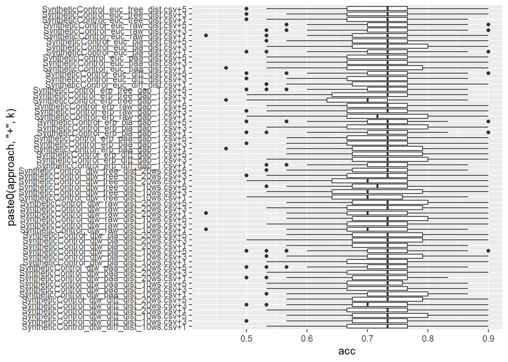

```r
require(ggplot2)
ggplot(overall_results,aes(x=paste0(approach,'+',k), y=acc)) +
geom_boxplot()+
coord_flip()
```